# Approaches to biomedical knowledge

Session #9: Transformer Architecture (Continued)

Peter N Robinson

Free University Berlin

2026-04-26

## Overview

**Game plan**

This lecture provides an introduction to the transformer architecture with a focus on the decoder.

Important: - https://arxiv.org/pdf/2305.17026

- Transformer models (recap)
- Decoder models
- Multihead attention
- Output generation
- Training LLMs
- KV Cache

## Transformer models

[figure not shown]

Amatriain X et al. (2024) [Transformer models: an introduction and catalog. arXiv 2302.07730](https://arxiv.org/abs/2302.07730)

## Transformer models

**An embarassment of riches**

- As can be seen in the previous slide, a large number of different transformer models have been developed
- They can be grouped largerly in encoder-decoder, encoder-only, and decoder-only
- The original paper, “Attention is all you need…”, described an encoder-decoder transformer
- This architecture is well suited for sequence-to-sequence tasks such as machine translation
- Last week, we focused on an introduction to the encoder model
- This week, we will provide additional detail and focus mainly on decoder-only models and on training

## Decoder models

A **decoder-only transformer** is an autoregressive neural network architecture that uses masked causal self-attention to predict the next token in a sequence.

- **Input processing**:
  - GPT-like models are decoder-only models
  - Inputs (i.e., tokenized prompt) are embedded and encoded
  - Positional encodings are added to the input embeddings
  - Attention calculation, similar to previously described
  - Large matrix multiplications, heavy usage of GPU hardward accelerator
  - Parallel process

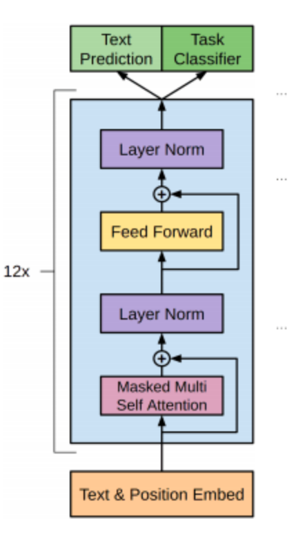

image: Perez L et al. (2021)[Automatic Code Generation using Pre-Trained Language Models. arXiv 2102.10535](https://arxiv.org/abs/2102.10535)

## Recap

- Recall encoder algorithm from the previous lecture:

| Tensor | Dimension | Example | Explanation |
| --- | --- | --- | --- |
| Input sequence [BOS] The quick brown fox jumps over the lazy dog [EOS] |  |  | Input tokens with additional beginning/end of sequence tokens |
| Tokenized Input sequence [50256, 791, 4062, 14198, 39935, 35308, 927, 279, 16053, 5679, 50256] | $N$ | $11$ | Number of tokens, including [BOS]/[EOS] |
| $\mathbf{X}$: Input embeddings | $N\times d_{hidden}$ | $11\times 512$ | $d_{hidden}$ is the embedding dimension |
| $\mathbf{W}^Q$: query weights $\mathbf{W}^K$: key weights $\mathbf{W}^V$: value weights | $d_{hidden}\times d_{hidden}$ | $512\times 512$ | Learnable model weights (single-head attention, so $d_k=d_{hidden}$) |
| $\mathbf{Q}=\mathbf{XW}^Q$: query matrix $\mathbf{K}=\mathbf{XW}^K$: key matrix $\mathbf{V}=\mathbf{XW}^V$: value matrix | $N\times d_{hidden}$ | $11\times 512$ | $\mathbf{Q}$: What each token needs to know from others $\mathbf{K}$: What information each token provides $\mathbf{V}$: Content each token shares when attended to |
| $\mathbf{QK}^T$: attention scores | $N\times N$ | $11\times 11$ | How well each token’s query matches the keys of the other tokens |
| $\mathrm{softmax}\left(\dfrac{\mathbf{QK}^T}{\sqrt{d_k}}\right)\mathbf{V}$ | $N\times d_{hidden}$ | $11\times 512$ | Attention weights applied to Values — context-aware token representations |
| $\times\ \mathbf{W}^O$: output projection *(optional here)* | $N\times d_{hidden}$ | $11\times 512$ | Required to combine multiple heads back to $d_{hidden}$; with a single head the shape already matches, so $W^O$ is optional (often kept anyway for extra learnable capacity) |
| Add & Norm | $N\times d_{hidden}$ | $11\times 512$ | Residual connection + LayerNorm (see Part 1) |
| FFN: $\text{GELU}(\mathbf{X}W_1+b_1)W_2+b_2$ | $N\times d_{hidden}$ | $11\times 512$ | Position-wise, applied independently per token; expands to $d_{ff}$ (e.g. $2048$) and projects back (see Part 1) |

This recap shows single-head attention, so $d_k=d_{hidden}$

Adapted from: Simon J Decoder-only inference: A step-by-step dive ([video](https://www.youtube.com/watch?v=cl3MAhAr9-M))

## Multihead attention

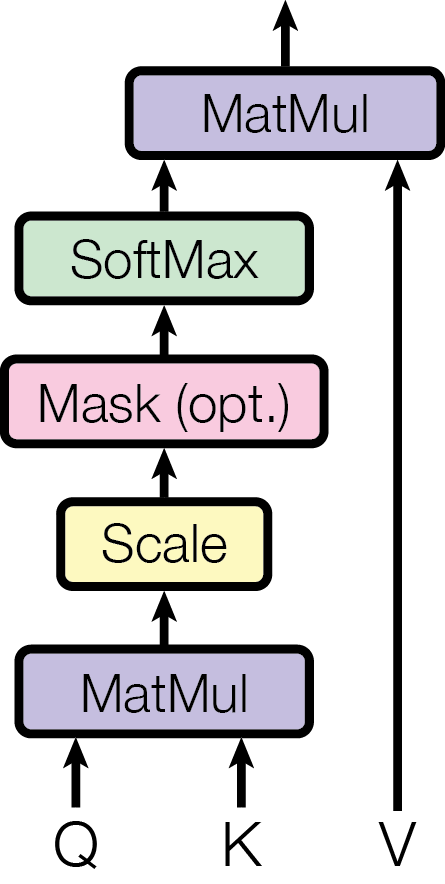

- Scaled dot-product attention

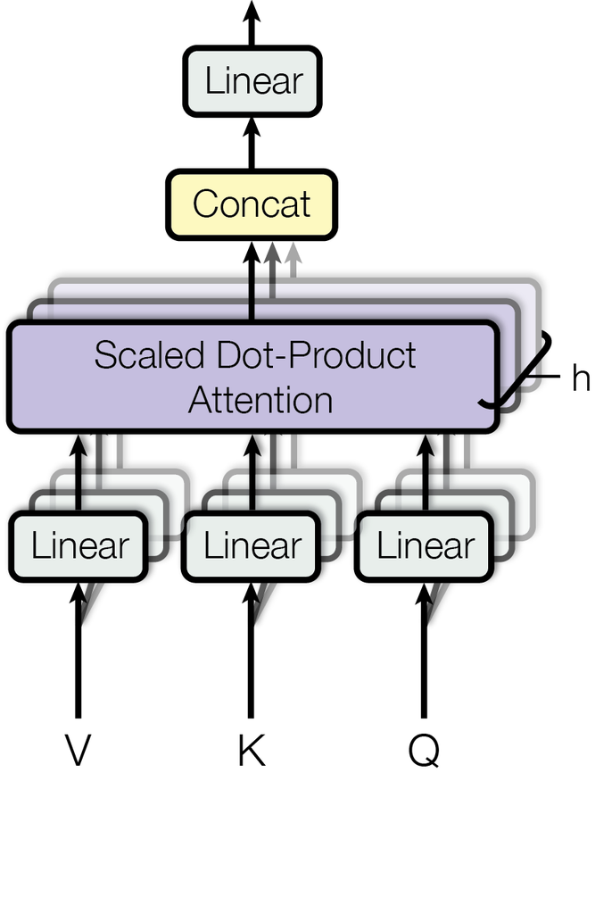

- Multihead attention – several attention layers running in parallel

[Vaswani A et al. (2017) Attention Is All You Need. arXiv 1706.03762](https://arxiv.org/abs/1706.03762)

## Multihead attention

- Instead of performing a single attention function with $d_{hidden}$-dimensional keys, queries, and values
- It is beneficial to linearly project the queries, keys, and values $h$ times with different linear Projections
- The results are concatenated and once again projected resulting in the final values

$$\mathrm{MultiHead}(Q,K,V) = \mathrm{Concat}(\mathrm{head}_1, \ldots,\mathrm{head}_h)\mathrm{W}^{O}$$
where
$$\mathrm{head}_i = \mathrm{Attention}(QW_i^Q, KW_i^K, VW_i^V)$$

- In the original paper, the authors use $h=8$ (8 heads)
- Then, $d_k=d_v=d_{hidden}/h = 64$ because $d_{hidden} =512$ (In the paper $d_{hidden}$ is called $d_{model}$)
- dimension check: $W_i^Q$ and $W_i^K$ are $d_{hidden}\times d_k$, $W_i^V$ is $d_{hidden}\times d_v$, and $\mathrm{W}^{O}$ is $hd_v \times d_{hidden}$

## Multihead attention

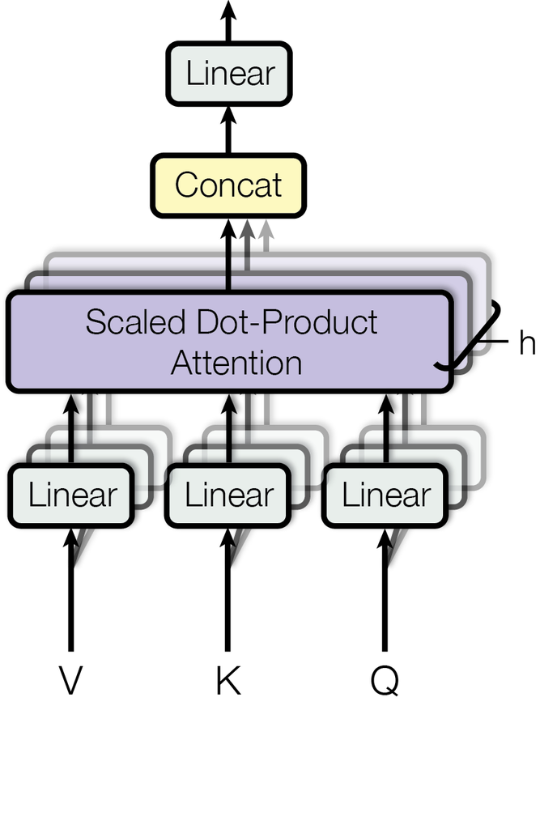

- All heads get the full input sequence, but only see a subset of the embedding dimensions
- Each head has its own Q,K,V matrices
- All heads compute attention scores in parallel
- Main benefit: Multihead attention allows the model to jointly attend to information from different representation subspaces at different positions. With a single attention head, averaging inhibits this.
- i.e., MHA yields better models!

[Vaswani A et al. (2017) Attention Is All You Need. arXiv 1706.03762](https://arxiv.org/abs/1706.03762)

## MHA step by step

| Tensor | Dimension | Example | Explanation |
| --- | --- | --- | --- |
| Input sequence [BOS] The quick brown fox jumps over the lazy dog [EOS] |  |  | Input tokens with additional beginning/end of sequence tokens |
| Tokenized Input sequence [50256, 791, 4062, 14198, 39935, 35308, 927, 279, 16053, 5679, 50256] | $N$ | $11$ | Number of tokens, including [BOS]/[EOS] |
| $\mathbf{X}$: Input embeddings | $N\times d_{hidden}$ | $11\times 512$ | $d_{hidden}$ is the embedding dimension |
| $\mathbf{W}^{Q_i}$: query weights $\mathbf{W}^{K_i}$: key weights $\mathbf{W}^{V_i}$: value weights | $d_{hidden}\times d_{mha}$ | $512\times 64$ | $d_{mha}=d_{hidden}/h$, where $h$ is the number of heads each head has its own weight matrices |
| $\mathbf{Q}_i=\mathbf{XW}^{Q_i}$: query matrix $\mathbf{K}_i=\mathbf{XW}^{K_i}$: key matrix $\mathbf{V}_i=\mathbf{XW}^{V_i}$: value matrix | $N\times d_{mha}$ | $11\times 64$ | all heads run in parallel |
| $\mathbf{Q}_i\mathbf{K}_i^T$: attention scores | $N\times N$ | $11\times 11$ | How well each token’s query matches the keys of the other tokens |
| $\mathrm{softmax}\left(\dfrac{\mathbf{Q}_i\mathbf{K}^T}{\sqrt{d_k}}\right)\mathbf{V}_i$ | $N\times d_{mha}$ | $11\times 64$ | Attention weights applied to Values — context-aware token representations |
| Concatenate head outputs | $N\times d_{hidden}$ | $11\times 512$ | Attention weights applied to Values — context-aware token representations |
| $\times\ \mathbf{W}^O$: output projection *(optional here)* | $N\times d_{hidden}$ | $11\times 512$ | Required to combine multiple heads back to $d_{hidden}$; with a single head the shape already matches, so $W^O$ is optional (often kept anyway for extra learnable capacity) |
| Add & Norm | $N\times d_{hidden}$ | $11\times 512$ | Residual connection + LayerNorm (see Part 1) |
| FFN: $\text{GELU}(\mathbf{X}W_1+b_1)W_2+b_2$ | $N\times d_{hidden}$ | $11\times 512$ | Position-wise, applied independently per token; expands to $d_{ff}$ (e.g. $2048$) and projects back (see Part 1) |

Adapted from: Simon J Decoder-only inference: A step-by-step dive ([video](https://www.youtube.com/watch?v=cl3MAhAr9-M))

## Output generation

- Unlike input generation, output generation is a sequential process
  - The answer is generated one token at a time
  - Each generated token is appended to the previous input
  - Process repeated until we get an $\langle \mathrm{EOS}\rangle$ token<sup>1</sup> or the maximum length is reached
[^1]: EOS=end of sequence

## Autoregressive text generation

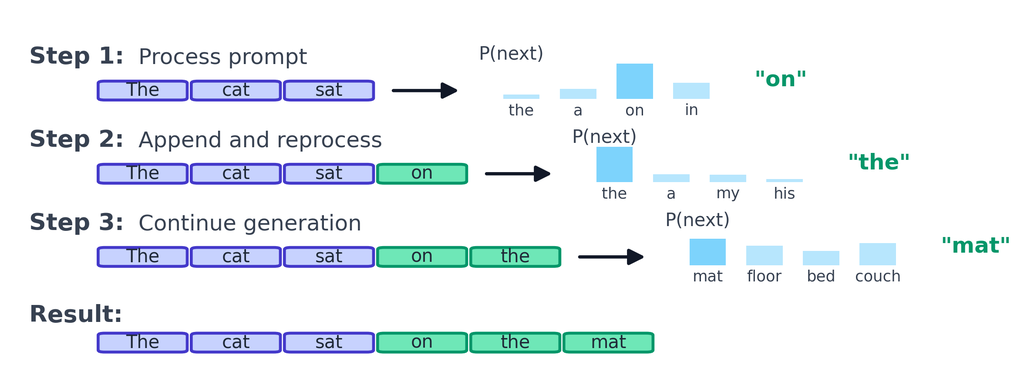

- Output is generated one token at a time

## Text generation: step by step

[output not shown]

## Token decoding: Deterministic Methods

**Deterministic methods**:

- generate text by selecting the continuation with the highest probability determined by the LM.
- Deterministic methods may lead to model degeneration
  - output becomes “unnatural”
  - output is marked repetitive and overly predictable language.
  - text lacks variety and fails to reflect natural human expression.

## Token decoding: greedy search

- Greedy search selects the word with the highest probability as its next word at each timestep

$$\arg \max_w P(w\mid w_1:w_{t-1})$$

- Greedy search continues in this way until reaching either an end-of-sequence (EOS) token or a maximum timestep $T$.
- Greedy search may overlook high-probability words that are accessible only after a lower-probability word.
- As a result, greedy decoding does not formally guarantee a global optimum of the decoding objective, as its choices are only locally optimal.
- Other deterministic methods include beam search and contrastive search

Wang, Haoran et al. (2026) [Beyond Tokens: A Survey on Decoding Methods for Large Language and Vision-Language Models. SIGKDD Explor. Newsl. 28:1931-0145](https://doi.org/10.1145/3820356.3820357)

## Token decoding: Stochastic methods

**Stochastic methods**:

Human-generated text exhibits greater variance in token probabilities, reflecting a diverse range of word choices, often unexpected.

In contrast, the output from deterministic methods shows minimal variance, resulting in more predictable and potentially repetitive text.

- Stochastic approaches introduce randomness during the decoding process, leading to more diverse and natural text generation.

## Token decoding: Top-$k$ sampling

- The $k$ most probable next words are selected<sup>1</sup>
- The probability of the $k$ top words is redistributed to form a new distribution, i.e., the probabilities of these k tokens are then normalized to sum to 1, resulting in a truncated distribution.
- A token is then randomly sampled from this distribution and appended to the current sequence.
- This process is repeated iteratively until a termination condition is satisfied.

Fan A (2018) [Hierarchical Neural Story Generation. arXiv 1805.04833]https://arxiv.org/abs/1805.04833)

[^2]: $k$ is typically to chosen to be a number such as 10, i.e., much less than the full token count

## Token decoding: Top-$p$ (Nucleus) Sampling

- Selects the smallest set of words whose cumulative probability meets or exceeds a predefined threshold $p$.
- Rather than sampling exclusively from the top $k$ most probable words, Top-$p$ redistributes the probability mass across this dynamic set.
- This adaptive approach allows the size of the word set (i.e., the number of included words) to increase or decrease based on the shape of the next-token probability distribution.
- Rest of approach is identical

Holtzman A (2020) [The Curious Case of Neural Text Degeneration. arXiv 1904.09751]https://arxiv.org/abs/1904.09751)

## Token decoding: Temperature Sampling

- The core idea of temperature sampling is to control the “sharpness” of the probability distribution by introducing a temperature parameter $t$.
- This parameter is applied in the softmax function after the transformer’s final layer to compute token probabilities.
- The temperature t directly influences the level of randomness in the sampling process, with higher values increasing randomness and lower values reducing it.

## Token decoding: Temperature Sampling

- The core idea of temperature sampling is to control the “sharpness” of the probability distribution by introducing a temperature parameter $t$.
- This parameter is applied in the softmax function after the transformer’s final layer to compute token probabilities.
- The temperature $t$ directly influences the level of randomness in the sampling process, with higher values increasing randomness and lower values reducing it.<sup>1</sup>

$$P(x_i) = \frac{\exp(z_i / t)}{\sum_j \exp(z_j / t)}$$

- $t=1$: standard softmax (no change)
- $t<1$: sharper distribution — closer to greedy/argmax as $t\to 0$
- $t>1$: flatter distribution — closer to uniform as $t\to\infty$
[^3]: Hinton G, Vinyals O, Dean J (2015) Distilling the Knowledge in a Neural Network. arXiv:1503.02531

## Temperature: worked example

- Let the following be the logits for the next token after “The cat sat on the”:

| token | logit $z_i$ |
| --- | --- |
| mat | 2.0 |
| floor | 1.0 |
| bed | 0.1 |
| couch | -1.0 |

|  | Temperature | mat | floor | bed | couch |
| --- | --- | --- | --- | --- | --- |
| 0 | t=0.5 | 0.862 | 0.117 | 0.019 | 0.002 |
| 1 | t=1.0 | 0.638 | 0.235 | 0.095 | 0.032 |
| 2 | t=2.0 | 0.451 | 0.274 | 0.174 | 0.101 |

## Combining temperature with top-$k$ / top-$p$

- Temperature and truncation (top-$k$, top-$p$) are typically applied together, in sequence:
  1. Scale logits by $1/t$
  2. Apply softmax to get the temperature-adjusted distribution
  3. Truncate: keep only the top-$k$ tokens, or the smallest set whose cumulative probability exceeds $p$ (nucleus sampling)<sup>1</sup>
  4. Renormalize the remaining probabilities to sum to 1
  5. Sample from the renormalized distribution
- Example: applying top-$k=2$ after $t=0.5$ scaling keeps only {mat: 0.862, floor: 0.117}, renormalized to {mat: 0.880, floor: 0.120} — “bed” and “couch” are excluded entirely
- Intuition:
  - temperature reshapes *how peaked* the whole distribution is
  - top-$k$/top-$p$ decide *how much of the tail* is eligible for sampling at all.
- Many chat APIs expose both `temperature` and `top_p` as independent parameters.
[^4]: Holtzman A, et al. (2020) The Curious Case of Neural Text Degeneration. ICLR 2020

## Training LLMs

- The next sections will cover several aspects of how to train LLMs
- For the most part, LLMs are synonymous with decoder-only transformers; from now on we will say LLM for conciseness.

## Training LLMs: Causal (Masked) Self-Attention

**The problem**

- Encoder self-attention lets every token attend to every other token — including tokens that come *later* in the sequence.
- A decoder predicts tokens one at a time, left to right. If some token $i$ can attend to a token $j$ during training with $j>i$, the model can simply “read the answer” instead of learning to predict it.
- This would make the training loss trivially low — the model learns nothing about actually predicting the future, since the future is already visible.
- We need a mechanism that lets us train on the full sequence in parallel (for efficiency), while still preventing this kind of “leakage.”

## Masked Self-Attention

- Recall: $\text{Attention}(Q,K,V) = \text{softmax}\left(\dfrac{QK^\top}{\sqrt{d_k}}\right)V$
- We modify this by adding a **mask matrix** $M$ to the scores, *before* the softmax step:

$$\text{MaskedAttention}(Q,K,V) = \text{softmax}\left(\frac{QK^\top}{\sqrt{d_k}} + M\right)V$$

- $M$ is an $n\times n$ matrix, defined entrywise as:

$$M_{i,j} = \begin{cases} 0 & j \le i \quad \text{(allowed: current or past token)} \\ -\infty & j > i \quad \text{(disallowed: future token)} \end{cases}$$

- Adding $-\infty$ to a score, then applying softmax, transforms the entry tp exactly $0$.
- In practice, implementations use a large negative finite number (e.g. $-10^9$) instead of literal $-\infty$, for numerical stability — the same spirit as the $\epsilon$ we added inside LayerNorm in Part 1.<sup>1</sup>
[^5]: Phuong M, Hutter M (2022) Formal Algorithms for Transformers. arXiv:2207.09238

## Worked Example: The Mask Matrix

- For our 4-token sentence “I am an automaton” ($n=4$), the mask matrix is:

$$M = \begin{bmatrix}
0 & -\infty & -\infty & -\infty \\
0 & 0 & -\infty & -\infty \\
0 & 0 & 0 & -\infty \\
0 & 0 & 0 & 0
\end{bmatrix}$$

- Row $i$ corresponds to the query token; column $j$ to the key token.
- Row 0 (“I”): only column 0 is unmasked — the first token can only attend to itself.
- Row 3 (“automaton”): all four columns are unmasked — the last token can attend to the entire sequence, since nothing comes after it.
- Causal masking is often just called “triangular masking.”

## Worked Example: From Raw Scores to Masked Attention Weights

Suppose the raw attention scores $S =\frac{QK^\top}{\sqrt{d_k}}$ for our sentence. - The masking procedure is as follows

$$\mathbf{S} + \mathbf{M} = \begin{bmatrix}
0.9 & 0.2 & -0.1 & 0.4 \\
0.3 & 1.1 & 0.5 & -0.2 \\
0.1 & 0.4 & 1.3 & 0.6 \\
-0.2 & 0.3 & 0.7 & 1.5
\end{bmatrix} + \begin{bmatrix}
0 & -\infty & -\infty & -\infty \\
0 & 0 & -\infty & -\infty \\
0 & 0 & 0 & -\infty \\
0 & 0 & 0 & 0
\end{bmatrix}
=
\begin{bmatrix}
0.9 & -\infty & -\infty & -\infty \\
0.3 & 1.1 & -\infty & -\infty \\
0.1 & 0.4 & 1.3 &-\infty \\
-0.2 & 0.3 & 0.7 & 1.5
\end{bmatrix}$$

- Applying softmax row-by-row yields

$$\mathrm{softmax}(\mathbf{S} + \mathbf{M}) =
\begin{bmatrix}
1.0 & 0 & 0 & 0 \\
0.31 & 0,690 & 0 & 0 \\
0.176 & 0.238 & 0.586 &0 \\
0.094 & 0.156 & 0.232 & 0.517
\end{bmatrix}$$

- Row “I”: weight $[1.000, 0, 0, 0]$ — with only itself unmasked, softmax trivially assigns it all the probability mass.
- Row “am”: weight $\approx[0.310, 0.690, 0, 0]$ — splits attention only between “I” and “am”.
- Row “automaton”: weight $\approx[0.095, 0.156, 0.233, 0.517]$ — the only row using the **full** softmax, since nothing is masked.
- Notice the upper triangle is exactly $0$ in every row

## Pretraining

**Traditional ML**:

- train a separate model for each task from scratch
- Some ML tasks are similar. For instance
  - Spam detection
  - sentiment Analysis
  - machine translation
- All three tasks require the model to understand natural language
- The `transfer learning` approach reused a trained model for a new task by “tuning” the previously trained model
- LLMs take this approach to an extreme: Pretraining

## Pretraining

- Pre-training is the foundation for the power of Large Language Models (LLMs)
- Train by predicting the next work (token) on large collections of text data
- Most LLMs are trained on general data (“all” web pages, “all” books, etc.)
- Conversation text may help LLMs get better at chatting (train on social media data, e.g., Reddit)
- Books: May help LLMs “understand” complicated topics better than webpages/social media
- Stack exchange/GitHub: Help LLMs “understand” code

## Pretraining

- Size of training data

| LLM | Param count | Size |
| --- | --- | --- |
| GPT-3 (2020) | 175 billion | $\sim$ 350 GB |
| LLaMA-2 (2023) | 7B, 13B, 70B | $\sim$ 14 GB–140 GB |
| Llama 3 | 15 trillion tokens | $\sim$ 60 TB |
| GPT-4 | (Estimated)~1.8 trillion | Proprietary |

## Pretraining: Size matters

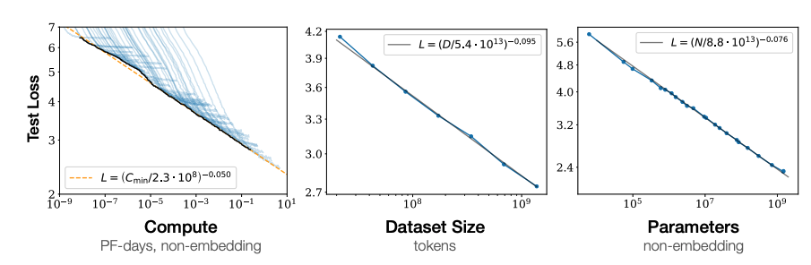

- Language modeling performance improves smoothly as we increase the model size, datasetset size, and amount of compute2 used for training.
- Coversely, the authors found very weak dependence on many architectural and optimization hyperparameters.

Kaplan J et al. (2020) [Scaling Laws for Neural Language Models. arXiv 2001.08361](https://arxiv.org/abs/2001.08361)

## Optimal model size

- On the other hand, what if we have a fixed compute budget and cannot increase the number of parameters or the amount of data without limit?
- The authors investigatef the optimal model size and number of tokens for training a transformer language model under a given compute budget.
- They found that current large language models are significantly undertrained, a consequence of the recent focus on scaling language models whilst keeping the amount of training data constant.

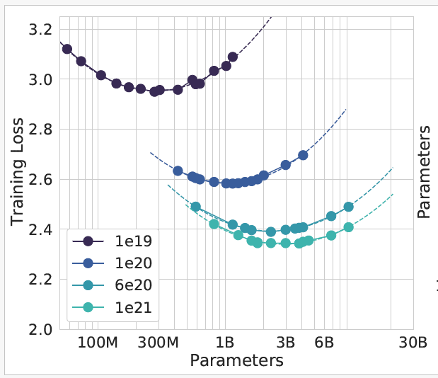

Hoffmann J et al. (2022) [Training Compute-Optimal Large Language Models. arXiv 2203.15556](https://arxiv.org/abs/2203.15556)

## Pretraining: Learning parameters

**Causal language modeling**

- A decoder is trained to predict each token given only the tokens that came before it.
- The basic back-propagation from previous lectures is used to train LLM parameters as well
- An Adam optimizer is most frequently used to implement gradient descent
- This is an **autoregressive** factorization of the joint probability of a sequence:

$$P(x_1,\ldots,x_n) = \prod_{t=1}^n P(x_t \mid x_1,\ldots,x_{t-1})$$

- The model doesn’t predict the whole sentence at once — it predicts one conditional distribution per position, and the chain rule of probability guarantees these conditionals multiply out to the joint probability of the full sequence.
- This factorization is exactly *why* causal masking (Section 2) is needed: each factor $P(x_t \mid x_1,\ldots,x_{t-1})$ must only depend on the past, or the factorization isn’t valid.

## The Loss Function

- Training uses **cross-entropy loss** between the predicted next-token distribution and the true next token.
- For a single position $t$, with true token $x_t$ and predicted probability $\hat{P}(x_t \mid x_{<t})$:

$$\mathcal{L}_t = -\log \hat{P}(x_t \mid x_1,\ldots,x_{t-1})$$

- The total loss for a sequence is the sum (or mean) over all positions:

$$\mathcal{L} = -\sum_{t=1}^n \log \hat{P}(x_t \mid x_1,\ldots,x_{t-1})$$

## Teacher forcing

- **Teacher forcing**: during training, the *true* previous tokens are fed as input at every position — not the model’s own (possibly wrong) predictions.
- This is what makes it possible to compute the loss for all $n$ positions in a single parallel forward pass, using the causal mask from Section 2 to prevent each position from seeing its own answer.
- At inference time there is no ground truth to feed back in — this is exactly the “Append and reprocess” loop from our decoding-steps diagram, where each new token is the model’s own prediction, fed back as input for the next step.

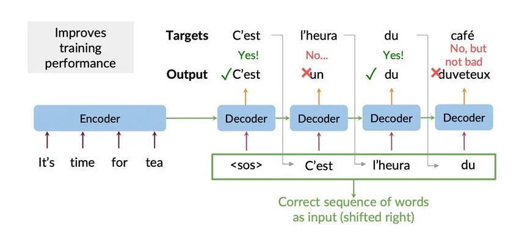

Image: https://www.deeplearning.ai/

## Worked Example: Cross-Entropy Loss

Continuing “I am an automaton” — suppose after “I am an” the model’s predicted distribution over the next token is:

| token | P(token) |
| --- | --- |
| automaton | 0.55 |
| apple | 0.05 |
| idea | 0.15 |
| the | 0.25 |

- The true next token is “automaton,” with predicted probability $0.55$.
- The loss at this position is $-\log(0.55) \approx 0.598$.
- If the model had instead assigned “automaton” a probability of, say, $0.01$, the loss would jump to $-\log(0.01)\approx 4.6$ — cross-entropy penalizes confident wrong predictions much more heavily than uncertain ones.

## KV Cache

- Let us return to the input processing (prefill) for decoder-only transformers
  - Inputs (tokenized prompt) are embedded and positionally encoded
  - Multihead attention (MHA) computes keys and values (KV)
  - Lots of matrix multiplications, high usage of hardware accelerator on the GPU
- Output is sequential (one token at a time)
  - Generated token is appended to previous input, …, again and again
  - MHA process is repeated each time
  - sequential means we cannot parallelize much!

## KV Cache

- Can we avoid recomputing KV values again and again?
- We only really need to compute KV values for the newly generated token
- The KV Cache stores the keys and values for all tokens we have previously generated

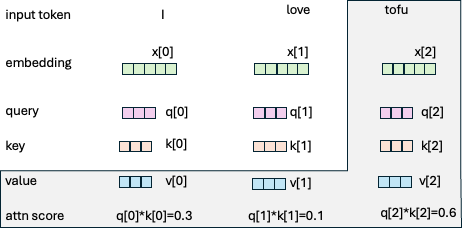

- We do not need to regenerate **keys** or **values** for “I” and “love” when we generate a new token “tofu”
- **Queries** are never cached and never reused, for any token, at any step.
  - a query is only ever used once, at the moment its own token is being generated, to compute that token’s output.
- We need to compute: Q, K, V for the new token “tofu”: all three must be computed fresh — Q because it’s a brand-new token needing its own query, and K/V because “tofu” also needs to contribute its own key/value pair to the cache for future tokens to attend to.

## KV Cache

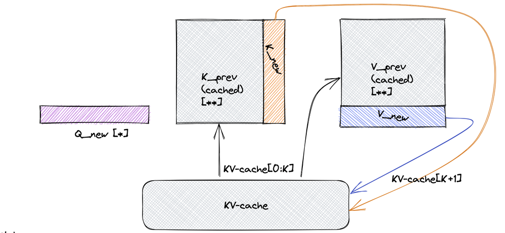

- When processing $\mathrm{token}[k]$, we only need the $k^{th}$ row of $\mathbf{Q}$.
- When processing $\mathrm{token}[k]$, we need the full $K$ and $V$ tensons, but we can mostly reuse the cached values
- Add the value for $k+1$ as we go along

Image credit: Generative LLM inference with Neuron (https://awsdocs-neuron.readthedocs-hosted.com/)

## KV Cache: Size

- The Cache size (FP16) can be calculated as

$$2\times 2\times\text{batch-size}\times\text{seq-length}\times\text{num-layers}\times\text{embedding dimension}$$
- We need to multiply by 2 because we have $K$ and $V$ - We need to multiply by 2 again because we have 16 bits (FP16) - Usually gigabytes of memory required - Many different attempts to shrink cache size to allow the batch size to be increased

**HBM**:

- The data for the KV Cache is typically stored in the High-Bandwidth Memory, which is **off GPU**
- Quadratic complexity for KV Cache access

## Multihead latent attention

- Introduced by DeepSeek for version 2

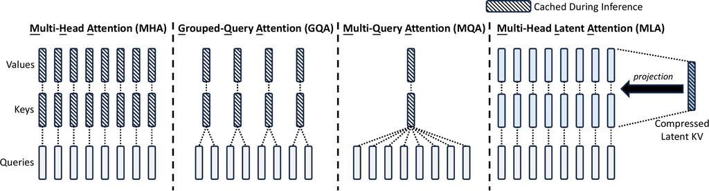

- Some previous approaches to reduce size of KV Cache used fewer keys and values (CQA, MQA)
- MLA
  - Does not cache K and V
  - uses a low-rank representation that is learned during training and cached
  - also learn a projection matrix to shring K and V during training
  - Much lower KV cache usage (90%+ savings)
  - 5-6x inference speedup
  - Hgher accuracy than vanilla MHA

## Multihead latent attention

| Tensor | Dimension | Example | Explanation |
| --- | --- | --- | --- |
| $\mathbf{X}$: input embeddings | $N\times d_{hidden}$ | $11\times 512$ | Embedded input tokens |
| $\mathbf{W}^{Q_i}$: query weights $\mathbf{W}^{K_i}$: key weights $\mathbf{W}^{V_i}$: value weights | $d_{hidden}\times d_{mha}$ | $512\times 64$ | $d_{mha}=d_{hidden}/h$, where $h$ is the number of heads each head has its own weight matrices |
| $W_{down}$: down-projection matrix $W_{up}$: up-projection matrix | $d_{mha}\times d_{mha-latent}$ $d_{latent}\times d_{hidden}$ | $64\times 4$ $32\times 512$ | $d_{latent}$ should be much smaller than $d_{hidden}$ (here, $d_{latent}=32$ and $d_{hidden}=512$) $d_{mha-latent} = d_{latent}/h$ where $h$ is the number of attention heads (e.g. $8$) |
| $\mathbf{Q}_i=\mathbf{XW}^{Q_i}$: query matrix $\mathbf{K}_i=\mathbf{XW}^{K_i}\mathbf{W}_{down}$: key matrix $\mathbf{V}_i=\mathbf{XW}^{V_i}\mathbf{W}_{down}$: value matrix | $N\times d_{mha}$ $N\times d_{mha-latent}$ | $11\times 64$ $11\times 4$ $11\times 4$ | all heads run in parallel |
| $\mathbf{Q}_i\mathbf{W}_{down}\mathbf{K}_i^T$: attention scores | $N\times N$ | $11\times 11$ | All heads run in parallel. $Q$ is down-projected for this calculation only and not cached. |
| $\mathrm{softmax}\left(\dfrac{\mathbf{Q}_i\mathbf{W}_{down}\mathbf{K}_i^T}{\sqrt{d_k}}\right)\mathbf{V}_i$ | $N\times d_{mha-latent}$ | $11\times 4$ | Attention weights applied to Values — all heads run this in parallel |
| Concatenate head outputs | $N\times d_{latent}$ | $11\times 32$ |  |
| $\mathrm{Outputs}\times \mathbf{W}_{up}$ | $N\times d_{hidden}$ | $11\times 512$ | Project output back to original dimension |
| Remaining steps | $\ldots$ | $\ldots$ | as before |

- The $d_{hidden}$ dimension is hurting us. Let’s downproject from 512 to 32.
- Because we are doing multihead attention, we project 64 to 4 (same factor)
- K and V are stored in KV cache and are $d_{hidden}/d_{latent}$ times smaller–$512/32=16$
- The tradeoff is that there is an extra matmut to compute $K_i$ and $V_i$
- $Q$ is not changed because it is not cached!

DeepSeek-AI (2024) [DeepSeek-V2: A Strong, Economical, and Efficient Mixture-of-Experts Language Model. arXiv 2405.04434](https://arxiv.org/abs/2405.04434)

## LORA

- We will return to low-rank approximation (LORA) in a subsequent lecture

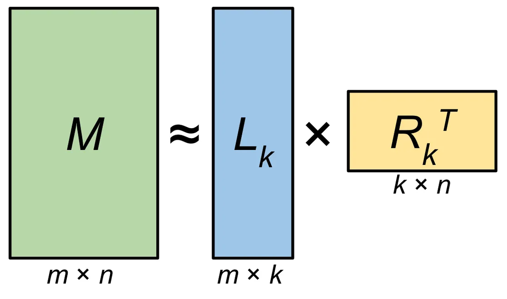

Lu J (2024) [Low-Rank Approximation, Adaptation, and Other Tales. arXiv 2408.05883](https://arxiv.org/abs/2408.05883)

## Sources

- Vaswani A et al. (2017) [Attention Is All You Need. arXiv 1706.03762](https://arxiv.org/abs/1706.03762)
- Turner RE (2026) [An Introduction to Transformers. arXiv 2304.10557](https://arxiv.org/abs/2304.10557)
- Allamar J (Blog) [The Illustrated GPT-2 (Visualizing Transformer Language Models)](https://jalammar.github.io/illustrated-gpt2/)
- Simon J Decoder-only inference: A step-by-step dive ([video](https://www.youtube.com/watch?v=cl3MAhAr9-M))